# Data Pre-processing

Liah Cha

June 26, 2017

## Data Pre-processing

- Data preparation take most of the time in Big Data Analytics
  - Objectives determination : 22%
  - Data Preperation : 56%
  - Data Mining : 12%
  - Analysis and ASsimilation : 10%

## Dummy Variables

- 어떤 값이 범주형 값일 수 있음 (예: 거주하고 있는 지역)

| X |  | Da | Db | Dc | … |
| --- | --- | --- | --- | --- | --- |
| D |  | 0 | 0 | 0 | … |
| B |  | 0 | 1 | 0 | … |
| C |  | 0 | 0 | 1 | … |
| C | -> | 0 | 0 | 1 | … |
| A |  | 1 | 0 | 0 | … |
| A |  | 1 | 0 | 0 | … |
| D |  | 0 | 0 | 0 | … |
| … |  |  |  |  | … |

```r
### Dummy variable ###
#install.packages("dummies", repos="http://healthstat.snu.ac.kr/CRAN/")
library(dummies)
data( iris )
head(iris, 10)
```

```
##    Sepal.Length Sepal.Width Petal.Length Petal.Width Species
## 1           5.1         3.5          1.4         0.2  setosa
## 2           4.9         3.0          1.4         0.2  setosa
## 3           4.7         3.2          1.3         0.2  setosa
## 4           4.6         3.1          1.5         0.2  setosa
## 5           5.0         3.6          1.4         0.2  setosa
## 6           5.4         3.9          1.7         0.4  setosa
## 7           4.6         3.4          1.4         0.3  setosa
## 8           5.0         3.4          1.5         0.2  setosa
## 9           4.4         2.9          1.4         0.2  setosa
## 10          4.9         3.1          1.5         0.1  setosa
```

```r
d <- dummy.data.frame( iris )
head(d)
```

```
##   Sepal.Length Sepal.Width Petal.Length Petal.Width Speciessetosa
## 1          5.1         3.5          1.4         0.2             1
## 2          4.9         3.0          1.4         0.2             1
## 3          4.7         3.2          1.3         0.2             1
## 4          4.6         3.1          1.5         0.2             1
## 5          5.0         3.6          1.4         0.2             1
## 6          5.4         3.9          1.7         0.4             1
##   Speciesversicolor Speciesvirginica
## 1                 0                0
## 2                 0                0
## 3                 0                0
## 4                 0                0
## 5                 0                0
## 6                 0                0
```

```r
iris$Ind1 <- as.numeric(iris$Species == 'setosa')
iris$Ind2 <- as.numeric(iris$Species == 'versicolor')
head(iris)
```

```
##   Sepal.Length Sepal.Width Petal.Length Petal.Width Species Ind1 Ind2
## 1          5.1         3.5          1.4         0.2  setosa    1    0
## 2          4.9         3.0          1.4         0.2  setosa    1    0
## 3          4.7         3.2          1.3         0.2  setosa    1    0
## 4          4.6         3.1          1.5         0.2  setosa    1    0
## 5          5.0         3.6          1.4         0.2  setosa    1    0
## 6          5.4         3.9          1.7         0.4  setosa    1    0
```

## Data Arrangement

< Long-Narrow >

| Acct | type |
| --- | --- |
| 2133 | MTG |
| 2133 | SVG |
| 2133 | CK |
| 2653 | CK |
| 2653 | SVG |
| 3544 | CK |
| 3544 | MMF |
| 3544 | CD |
| 3544 | LOC |

< Short-Wide >

[output not shown]

## Imputation Methods

- Substitutaion with a measure of **central tendency**
  - 평균 : Missing value는 평균으로 대체 (평균의 함정, outlier 왜곡 가능성 있음)
  1. Trimmed Mean (절사 평균) : 양 극단 5% 제외 등
  2. Mid-minimum spacing
  - P percent of the data is trimmed from each tail of the distribution
  - From the trimmed distribution, $(Max + Min)/2$
- Distribution based
- Tree Imputation
- **Regression Imputation**
- Imputation using the EM algorithm
- Multiple Imputation

```r
#install.packages("Hmisc", repos="http://cran.nexr.com")
library(Hmisc)
age <- c(1,2,NA,4)
age.i <- impute(age) # default = median value
# Could have used impute(age,2.5), impute(age,mean), impute(age,"random")
age.i
```

```
##  1  2  3  4
##  1  2 2*  4
```

```r
summary(age.i)
```

```
##
##  1 values imputed to 2
```

```
##    Min. 1st Qu.  Median    Mean 3rd Qu.    Max.
##    1.00    1.75    2.00    2.25    2.50    4.00
```

```r
is.imputed(age.i)
```

```
## [1] FALSE FALSE  TRUE FALSE
```

## Outlier Replacement

- 하한 값과 상한 값을 결정한 후,
- 어떤 값이 하한 값보다 적으면 하한 값으로 대체함
- 어떤 값이 상한 값보다 크면 상한 값으로 대체함
- 평균의 표준편차
  - 하한 값 = 평균 - n*표준편차
  - 상한 값 = 평균 + n*표준편차
  - n은 임계치 옵션에서 변경 가능함 (default는 3)
- 평균절대편차
  - 중위수로부터 n편차 큰 값을 대체
- 극 백분위수 (extreme percentiles)
  - 상위 p번째 백분위수보다 큰 값을 대체

## Variable Transformation

- 적절히 변환된 변수
  - 모형의 예측력 향상에 기여 가능
  - (예) 규모대비 매출액 : X10 = 매출, X11 = 규모 –> X10/X11 = X*10
- 변환의 종류
  - 자연로그 $Y = log(X)$
  - 제곱근 $Y = \sqrt{x}$
  - 역 $Y= 1/X$
  - 제곱 $Y = X^{2}$
  - 지수 $Y = EXP(X) = e^{X}$
  - 표준화 $Y = \frac{(X-μ)}{σ}$

## Example

#### HMEQ dataset

| 범주 | 변수이름 | 변수내용 |
| --- | --- | --- |
| 목표변수(=Y) | BAD | 신용상태0(좋음), 1(나쁨) |
| 대출신청서 | REASON | 대출사유 (빚정리, 주택개량) |
|  | JOB | 직업의 종류 (6개 범주) |
|  | LOAN | 대출금액 |
|  | MORTDUE | 저당금액 |
|  | VALUE | 현재 자산 |
|  | DEBTINC | 수입 대 부채비율(DTI) |
|  | YOJ | 현 직장 근무년수 |
| 신용정보기관 | DEROG | 주요 부실거래 수 |
|  | CLNO | 금융거래 수 |
|  | DELINQ | 부실거래 수 |
|  | CLAGE | 가장 오래된 거래의 개월 수 |
|  | NIMQ | 최근 신용상태 조회수 |

```r
### HMEQ data ###
#setwd("D:/jupyter/DataScience/ML")
hmeq<-read.table("./DMdata/hmeq.txt",header=T,sep='\t')
head(hmeq,10)
```

```
##    BAD LOAN MORTDUE  VALUE  REASON    JOB  YOJ DEROG DELINQ     CLAGE NINQ
## 1    1 1100   25860  39025 HomeImp  Other 10.5     0      0  94.36667    1
## 2    1 1300   70053  68400 HomeImp  Other  7.0     0      2 121.83333    0
## 3    1 1500   13500  16700 HomeImp  Other  4.0     0      0 149.46667    1
## 4    1 1500      NA     NA                  NA    NA     NA        NA   NA
## 5    0 1700   97800 112000 HomeImp Office  3.0     0      0  93.33333    0
## 6    1 1700   30548  40320 HomeImp  Other  9.0     0      0 101.46600    1
## 7    1 1800   48649  57037 HomeImp  Other  5.0     3      2  77.10000    1
## 8    1 1800   28502  43034 HomeImp  Other 11.0     0      0  88.76603    0
## 9    1 2000   32700  46740 HomeImp  Other  3.0     0      2 216.93333    1
## 10   1 2000      NA  62250 HomeImp  Sales 16.0     0      0 115.80000    0
##    CLNO  DEBTINC
## 1     9       NA
## 2    14       NA
## 3    10       NA
## 4    NA       NA
## 5    14       NA
## 6     8 37.11361
## 7    17       NA
## 8     8 36.88489
## 9    12       NA
## 10   13       NA
```

```r
levels(hmeq$REASON)[levels(hmeq$REASON)==""]<-NA
levels(hmeq$JOB)[levels(hmeq$JOB)==""]<-NA
head(hmeq,10)
```

```
##    BAD LOAN MORTDUE  VALUE  REASON    JOB  YOJ DEROG DELINQ     CLAGE NINQ
## 1    1 1100   25860  39025 HomeImp  Other 10.5     0      0  94.36667    1
## 2    1 1300   70053  68400 HomeImp  Other  7.0     0      2 121.83333    0
## 3    1 1500   13500  16700 HomeImp  Other  4.0     0      0 149.46667    1
## 4    1 1500      NA     NA    <NA>   <NA>   NA    NA     NA        NA   NA
## 5    0 1700   97800 112000 HomeImp Office  3.0     0      0  93.33333    0
## 6    1 1700   30548  40320 HomeImp  Other  9.0     0      0 101.46600    1
## 7    1 1800   48649  57037 HomeImp  Other  5.0     3      2  77.10000    1
## 8    1 1800   28502  43034 HomeImp  Other 11.0     0      0  88.76603    0
## 9    1 2000   32700  46740 HomeImp  Other  3.0     0      2 216.93333    1
## 10   1 2000      NA  62250 HomeImp  Sales 16.0     0      0 115.80000    0
##    CLNO  DEBTINC
## 1     9       NA
## 2    14       NA
## 3    10       NA
## 4    NA       NA
## 5    14       NA
## 6     8 37.11361
## 7    17       NA
## 8     8 36.88489
## 9    12       NA
## 10   13       NA
```

```r
hmeq$BAD<-factor(hmeq$BAD) #BAD를 범주형 변수로 변환 (기존 integer 정수)
class(hmeq$BAD)
```

```
## [1] "factor"
```

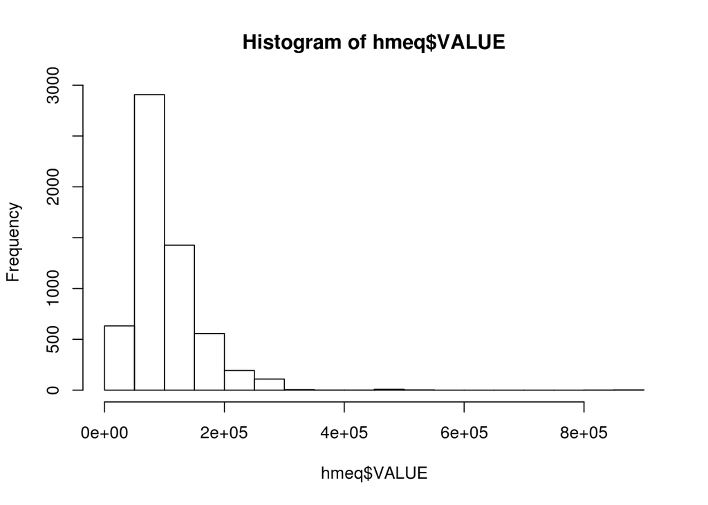

```r
hist(hmeq$VALUE)
```

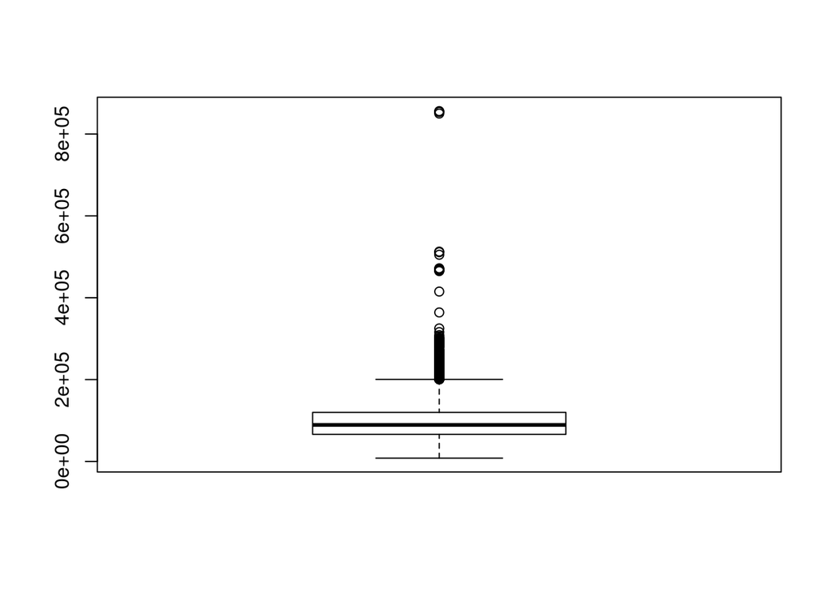

```r
boxplot(hmeq$VALUE)
```

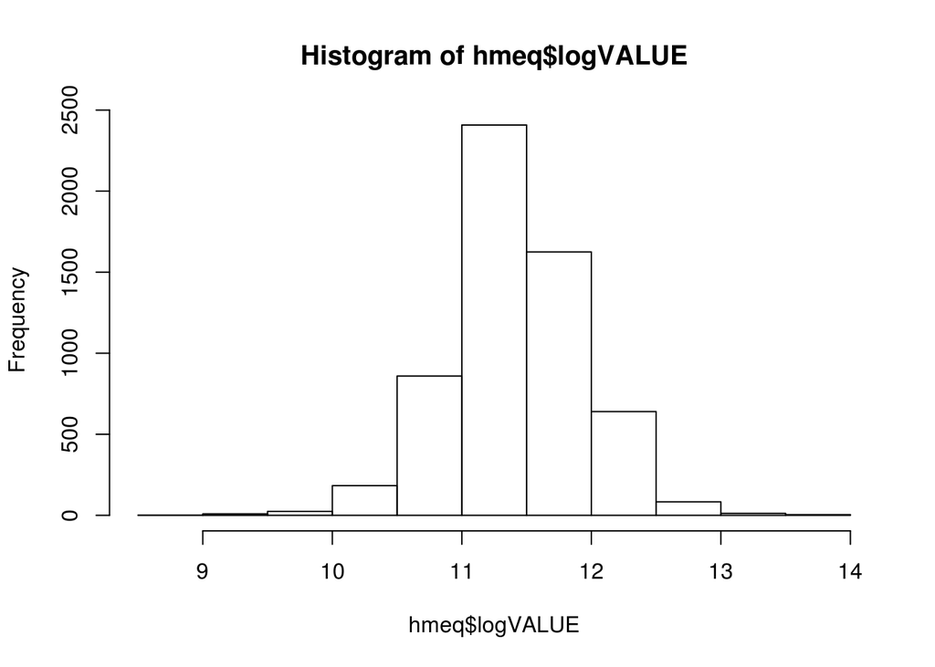

```r
hmeq$logVALUE=log(hmeq$VALUE)
hist(hmeq$logVALUE)
```